# Plot ratios of unconjugated to conjugated Bile Acids from Sato el al., Nature, 2021

Data from Sato et al., Nature, 2021 https://www.nature.com/articles/s41586-021-03832-5#MOESM6

According to the paper: - centenarian (average age, 107 years old; n = 160); - elderly (85–89 years old; n = 112); - young (21–55 years old; n = 47).

Data was downloaded from https://www.metabolomicsworkbench.org/data/show_metabolites_by_study.php?STUDY_ID=ST001851&STUDY_TYPE=MS&RESULT_TYPE=1 by selecting metabolites ratios of interest (CA and TCA; DCA and TDCA; CDCA and TCDCA). Tables were combined into one excel file (“../data/Sato_etal_bileacids_metabolomicsworkbench.xlsx”)

```r
library(readxl)
library(tidyverse)
library(ggbeeswarm)
library(ggpubr)

theme_set(theme_bw())
main_infile <- "../data/Sato_etal_bileacids_metabolomicsworkbench.xlsx"

read_main_data <- function(i, inpath = main_infile) {

  # i is the number of the sheet
  grps <- c( "Young", "Elderly","Centenarian")

  df <- read_excel(path = inpath, sheet = i) %>%
    mutate(age_status = as.factor(gsub("Category:", "", Factors)))  %>%
    subset(age_status %in% grps)  %>%
    mutate(age_status = fct_relevel(age_status, grps))

  return(df)
}

plot_results <- function(dat) {


  print(colnames(dat)[[4]])

  col_id <- colnames(dat)[[4]]

  p1 <- dat %>%
  mutate(log_ratio=log2(get(col_id))) %>%
  drop_na(log_ratio) %>%
  ggplot(aes(x=age_status , color=age_status, y=log_ratio)) +
 # stat_compare_means(label = "p.signif") +
  stat_compare_means(comparisons = list(c(1,2), c(2,3), c(1,3))) +
  scale_fill_brewer(palette = "Dark2") +
  scale_color_brewer(palette = "Dark2") +
  geom_point() +
  geom_boxplot(alpha=0.3) +
  theme(axis.text.x = element_text(angle = 45, vjust = 0.5),
        panel.grid.major = element_blank(),
        panel.grid.minor = element_blank())+
  ylab(gsub("Ratio", "", col_id))

  return(p1)
}
```

## Plot ratios of deconjugated/conjugated bile acids for all samples

```r
main_plots <- lapply((1:3), function(x) {

  read_main_data(i = x) %>%
    plot_results() -> p1

  return(p1)
})
```

```
[1] "CA/TCA Ratio"
[1] "DCA/TDCA Ratio"
[1] "CDCA/TCDCA Ratio"
```

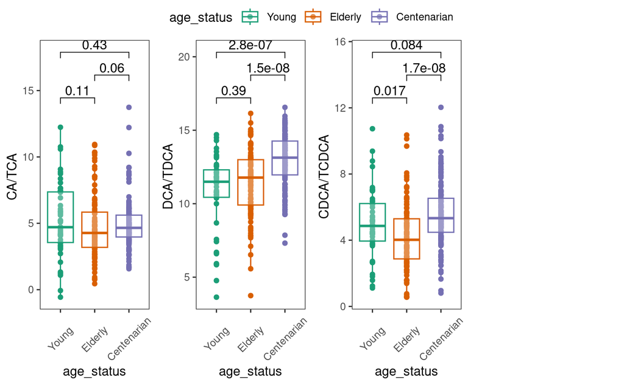

```r
ggpubr::ggarrange(plotlist = main_plots, common.legend = T, ncol=4)
ggsave("./main_human_ratios.pdf")
```

## Get adjusted p-values

```r
# Combine datasets
cdat <- lapply(1:3, function(x) {

  df <- read_main_data(i=x) %>%
    select(1,4,7) %>%
    mutate(ba_name = colnames(.)[2]) %>%
    rename_with(.cols = 2, ~"Ratio")

  return(df)

}) %>%
 data.table::rbindlist() %>%
  as.data.frame()


# Run stats for all comparisons of interest
compare_means(Ratio ~ age_status, group.by = "ba_name", data = cdat)
```

| ba_name | .y. | group1 | group2 | p | p.adj | p.format | p.signif | method |
| --- | --- | --- | --- | --- | --- | --- | --- | --- |
| CA/TCA Ratio | Ratio | Young | Elderly | 1.138980e-01 | 3.4e-01 | 0.114 | ns | Wilcoxon |
| CA/TCA Ratio | Ratio | Young | Centenarian | 4.282541e-01 | 7.8e-01 | 0.428 | ns | Wilcoxon |
| CA/TCA Ratio | Ratio | Elderly | Centenarian | 6.012424e-02 | 3.0e-01 | 0.060 | ns | Wilcoxon |
| DCA/TDCA Ratio | Ratio | Young | Elderly | 3.891099e-01 | 7.8e-01 | 0.389 | ns | Wilcoxon |
| DCA/TDCA Ratio | Ratio | Young | Centenarian | 2.820876e-07 | 2.0e-06 | 2.8e-07 | **** | Wilcoxon |
| DCA/TDCA Ratio | Ratio | Elderly | Centenarian | 1.461104e-08 | 1.3e-07 | 1.5e-08 | **** | Wilcoxon |
| CDCA/TCDCA Ratio | Ratio | Young | Elderly | 1.666059e-02 | 1.0e-01 | 0.017 | * | Wilcoxon |
| CDCA/TCDCA Ratio | Ratio | Young | Centenarian | 8.428546e-02 | 3.4e-01 | 0.084 | ns | Wilcoxon |
| CDCA/TCDCA Ratio | Ratio | Elderly | Centenarian | 1.661234e-08 | 1.3e-07 | 1.7e-08 | **** | Wilcoxon |

```r
NA
```

From Sato et al 2021, a few more details about metagenomic samples: “Principal coordinate analysis based on species-level Bray–Curtis dissimilarity from the assembled faecal metagenomes of centenarian [CE, n = 176, orange (154 individuals: 3 participants undergoing antibiotic treatment and 3 with insufficient bacterial DNA yield were excluded from the total 160 participants; analysis also included samples collected twice from 20 individuals and three times from 1 individual with an intervening one or two year interval)], older [n = 110, blue (110 individuals: 1 participant undergoing antibiotics treatment and 1 participant with insufficient bacterial DNA yield were excluded from 112 participants)], and young [n = 44, grey (44 individuals: 3 participants with insufficient bacterial DNA yield were excluded from 47 participants]”

I am not sure which samples are from the same individual and which ones are from participants undergoing antibiotic treatment. If we could have more information related to that, it would be helpful to decide on how to properly filter the data.